# Meta-Workflow

Miao Yu

August 16, 2016

# Introduction

The workflow of the metabolomic study always began with data collection and ended with certain scientific problem. It always showed the following workflow:

1. Experimental design(DoE)
2. Raw data collection
3. Feature detection
4. Data correction
5. Statistic analysis
6. Annotation
7. Omics analysis

# Project Setup

I suggest to build your data analysis project in RStudio(Click File - New project - New dictionary - Empty project). Then assign a name for your project. I recommend the following tips if you are familiar with it.

- Use [git](https://git-scm.com/)/[github](https://github.com/) to make version control of your code and sync your project online.
- NOT use your name for your project because other peoples might cooperate with you and someone might check your data when you publish your papers. Each project should be a work for one paper or one chapter in your thesis.
- Use **workflow** document(txt or doc) in your project to record all of the steps and code you performed for this project. Treat this document as digital version of your experiment notebook
- Use **data** folder in your project folder for the raw data and the results you get in data analysis
- Use **figure** folder in your project folder for the figure
- Use **munuscript** folder in your project folder for the manuscript (you could write paper in rstudio with the help of template in [Rmarkdown](https://github.com/rstudio/rticles))
- The best way to begin your study with project is copy the contents in this folder into your new project folder. Remember not copy the **metademo.Rproj** into your folder because you already have one.
- Just double click **[yourprojectname].Rproj** to start your project

# Exprimental design(DoE)

Before you perform any metabolomic studies, a clean and meaningful experimental design is always the best start. You need two groups at least: treated group and control group.

If there are other co-factors, a Linear model or randomizing would be applied to eliminated their influences. You need to record the values of those co-factors for further data analysis. Common co-factors in metabolomic studies are age, gender, location, etc.

If you need data correction, some background or calibration samples are required. However, control samples could also be used for data correction in certain DoE.

# Raw data collection

Collection of your Raw data from the instrument such as LC-MS or GC-MS is the beginning of data analysis.

However, **xcms** does not support all of the Raw files from every mass spectrometry manufacturers. You need to convert your Raw data into some open-source [data format](https://en.wikipedia.org/wiki/Mass_spectrometry_data_format) such as mzData, mzXML or CDF files. The tool is **MScovert** from [**ProteoWizard**](http://proteowizard.sourceforge.net/).

Here is a demo:

```r
# install the packages for data analysis and
# source("https://bioconductor.org/biocLite.R")
# biocLite(c("multtest","faahKO","xcms","qvalue","CAMERA","ropls"))
# load the functions and dataset for demo

library(multtest)
library(xcms)
library(faahKO)
# get the demo data in faahKO packages
cdfpath <- system.file("cdf",package = "faahKO")
# show the name of demo data
list.files(cdfpath,recursive = T)
```

```
##  [1] "KO/ko15.CDF" "KO/ko16.CDF" "KO/ko18.CDF" "KO/ko19.CDF" "KO/ko21.CDF"
##  [6] "KO/ko22.CDF" "WT/wt15.CDF" "WT/wt16.CDF" "WT/wt18.CDF" "WT/wt19.CDF"
## [11] "WT/wt21.CDF" "WT/wt22.CDF"
```

# Feature detection

The first step to process the MS data is that find the peaks against the noises. In **xcms**, all of related staffs are handled by *xcmsSet* function.

For any functions in **xcms** or **R**, you could get their documents by type `?` before certain function. Another geek way is input the name of the function in the console of Rstudio and press F1 for help.

```r
?xcmsSet
```

In the document of *xcmsset*, we could set the sample classes, profmethod, profparam, polarity,etc. In the online version, such configurations are shown in certain windows. In the local analysis environment, such parameters are setup by yourselves. However, I think the default configurations could satisfied most of the analysis because related information should have been recorded in your Raw data and **xcms** could find them. All you need to do is that show the data dictionary for *xcmsSet*.

If your data have many groups such as control and treated group, just put them in separate subfolder of the data folder and *xcmsSet* would read them as separated groups.

Here is a demo for *xcmsSet*:

```r
cdffiles <- list.files(cdfpath, recursive = TRUE, full.names = TRUE)
xset <- xcmsSet(cdffiles)
```

```
## 250:38 300:103 350:226 400:338 450:431 500:529 550:674 600:847
## 250:43 300:128 350:275 400:394 450:500 500:637 550:835 600:1027
## 250:25 300:93 350:227 400:337 450:411 500:498 550:640 600:758
## 250:19 300:67 350:169 400:258 450:301 500:373 550:488 600:580
## 250:24 300:60 350:166 400:254 450:315 500:391 550:501 600:582
## 250:31 300:71 350:183 400:280 450:338 500:422 550:532 600:604
## 250:41 300:105 350:212 400:319 450:416 500:533 550:684 600:838
## 250:27 300:107 350:232 400:347 450:440 500:549 550:712 600:905
## 250:24 300:87 350:200 400:293 450:351 500:426 550:548 600:661
## 250:22 300:65 350:161 400:243 450:293 500:358 550:483 600:561
## 250:28 300:69 350:157 400:229 450:282 500:364 550:493 600:592
## 250:30 300:81 350:188 400:280 450:356 500:473 550:618 600:765
```

```r
xset
```

```
## An "xcmsSet" object with 12 samples
##
## Time range: 2506.1-4147.7 seconds (41.8-69.1 minutes)
## Mass range: 200.1-599.3338 m/z
## Peaks: 4721 (about 393 per sample)
## Peak Groups: 0
## Sample classes: KO, WT
##
## Peak picking was performed on MS1.
## Profile settings: method = bin
##                   step = 0.1
##
## Memory usage: 0.713 MB
```

The output was an object with class of *xcmsSet*. You could see a summary by type the name. In this cases, *xcmsSet* found 4721 peaks with time range 41.8-69.1 min and mass range 200.1-599.3338 m/z in the 12 samples.

Another function which might be useful is `group`. This function will add additional information about the same analytes for `xcmsSet` objects.

```r
xset <- group(xset)
```

```
## 262 325 387 450 512 575
```

```r
xset
```

```
## An "xcmsSet" object with 12 samples
##
## Time range: 2506.1-4147.7 seconds (41.8-69.1 minutes)
## Mass range: 200.1-599.3338 m/z
## Peaks: 4721 (about 393 per sample)
## Peak Groups: 403
## Sample classes: KO, WT
##
## Peak picking was performed on MS1.
## Profile settings: method = bin
##                   step = 0.1
##
## Memory usage: 0.777 MB
```

Now you see there are 403 groups in the demo data, which meant 403 analytes are found across 4721 peaks.

# Data correction

Reasons of data correction might come from many aspects such as the unstable instrument and pollution on column. In **xcms**, the most important correction is retention time correction.

The basic idea behind retention time correction is that use the high quality grouped peaks to make a new retention time. You might choose obiwarp(recommended, see this [paper](http://pubs.acs.org/doi/abs/10.1021/ac0605344)) or loess(defaulted) method to get the corrected retention time for all of the samples. Remember the original retention time might changed and use another object to save the new object:

```r
xset2 <- retcor(xset, method = "obiwarp")
```

```
## center sample:  ko16
## Processing: ko15  ko18  ko19  ko21  ko22  wt15  wt16  wt18  wt19  wt21  wt22
```

```r
xset2
```

```
## An "xcmsSet" object with 12 samples
##
## Time range: 2506.3-4162.2 seconds (41.8-69.4 minutes)
## Mass range: 200.1-599.3338 m/z
## Peaks: 4721 (about 393 per sample)
## Peak Groups: 0
## Sample classes: KO, WT
##
## Peak picking was performed on MS1.
## Profile settings: method = bin
##                   step = 0.1
##
## Memory usage: 0.713 MB
```

```r
# you need group the peaks again for this corrected data
xset2 <- group(xset2)
```

```
## 262 325 387 450 512 575
```

```r
xset2
```

```
## An "xcmsSet" object with 12 samples
##
## Time range: 2506.3-4162.2 seconds (41.8-69.4 minutes)
## Mass range: 200.1-599.3338 m/z
## Peaks: 4721 (about 393 per sample)
## Peak Groups: 404
## Sample classes: KO, WT
##
## Peak picking was performed on MS1.
## Profile settings: method = bin
##                   step = 0.1
##
## Memory usage: 0.777 MB
```

You see one more peak groups after the correction. After the retention time correction, we also need to correct the peak groups by filling the missing peaks. Such function calls *fillpeaks*:

```r
xset3 <- fillPeaks(xset2)
```

```
## /Library/Frameworks/R.framework/Versions/3.3/Resources/library/faahKO/cdf/KO/ko15.CDF
## /Library/Frameworks/R.framework/Versions/3.3/Resources/library/faahKO/cdf/KO/ko16.CDF
## /Library/Frameworks/R.framework/Versions/3.3/Resources/library/faahKO/cdf/KO/ko18.CDF
## /Library/Frameworks/R.framework/Versions/3.3/Resources/library/faahKO/cdf/KO/ko19.CDF
## /Library/Frameworks/R.framework/Versions/3.3/Resources/library/faahKO/cdf/KO/ko21.CDF
## /Library/Frameworks/R.framework/Versions/3.3/Resources/library/faahKO/cdf/KO/ko22.CDF
## /Library/Frameworks/R.framework/Versions/3.3/Resources/library/faahKO/cdf/WT/wt15.CDF
## /Library/Frameworks/R.framework/Versions/3.3/Resources/library/faahKO/cdf/WT/wt16.CDF
## /Library/Frameworks/R.framework/Versions/3.3/Resources/library/faahKO/cdf/WT/wt18.CDF
## /Library/Frameworks/R.framework/Versions/3.3/Resources/library/faahKO/cdf/WT/wt19.CDF
## /Library/Frameworks/R.framework/Versions/3.3/Resources/library/faahKO/cdf/WT/wt21.CDF
## /Library/Frameworks/R.framework/Versions/3.3/Resources/library/faahKO/cdf/WT/wt22.CDF
```

```r
xset3
```

```
## An "xcmsSet" object with 12 samples
##
## Time range: 2502.9-4162.2 seconds (41.7-69.4 minutes)
## Mass range: 200.1-599.3338 m/z
## Peaks: 6054 (about 504 per sample)
## Peak Groups: 404
## Sample classes: KO, WT
##
## Peak picking was performed on MS1.
## Profile settings: method = bin
##                   step = 0.1
##
## Memory usage: 0.918 MB
```

You see more peaks found.

# Statistic analysis

Right now we get peaks across samples, the next step is finding the differences between two groups. Actually, you could perform ANOVA or Kruskal-Wallis Test for comparison among more than two groups. The basic idea behind statistic analysis is to find the meaningful differences between groups and extract such ions or peak groups. So, you will find the P values of t-test for pairwise comparison:

```r
reporttab <- diffreport(xset3, "WT", "KO", "example")
reporttab[1:3,]
```

```
##        name     fold    tstat       pvalue    mzmed    mzmin    mzmax
## 1 M300T3391 5.693594 14.44368 5.026336e-08 300.1898 300.1706 300.2000
## 2 M301T3391 6.283030 15.52501 5.385022e-08 301.1879 301.1659 301.1949
## 3 M298T3185 3.984984 11.88773 3.615841e-07 298.1508 298.1054 298.1592
##      rtmed    rtmin    rtmax npeaks KO WT      ko15      ko16      ko18
## 1 3390.699 3374.142 3398.743     12  6  6 4534353.6 4980914.5 5290739.1
## 2 3391.126 3385.366 3394.937      7  6  1  962353.4 1047934.1 1109303.0
## 3 3185.221 3182.083 3190.163      4  4  0  180780.8  204134.9  191015.9
##        ko19      ko21      ko22      wt15      wt16      wt18      wt19
## 1 4564262.9 4733236.1 3931592.6 349660.89 491793.18 645526.70 634108.85
## 2  946943.4  984787.2  806171.5  80639.28 118940.90 134531.39 102784.65
## 3  190626.8  155276.9  220288.6  16448.42  41050.04  50082.55  76704.81
##         wt21       wt22
## 1 1438254.45 1364627.84
## 2  203982.76  291392.97
## 3   53957.78   48363.33
```

Now you have got the ions that varies a lot between groups. Such ions are things we should take care of. In a ideal case, this is the endpoint of your study and the left work is making a report of your finding.

However, you might find too many ions and also hundreds of comparison would also show many high false-positive ions. In statistics, you need a false discovery rate(FDR) control. I suggested q-values instead of p-values to control FDR. If q-value is 0.05, we should expect 5% of all the compounds with q-value less than this to be false positives.

To get the q-values, you need input p-values and use the function from **qvalue** package.

```r
library(qvalue)
# extract the p-value to caculate q-value
qvalue <- qvalue(p=reporttab$pvalue)
# add qvalue to reporttab
reporttab$qvalue <- qvalue$qvalues
reporttab[1:3,]
```

```
##        name     fold    tstat       pvalue    mzmed    mzmin    mzmax
## 1 M300T3391 5.693594 14.44368 5.026336e-08 300.1898 300.1706 300.2000
## 2 M301T3391 6.283030 15.52501 5.385022e-08 301.1879 301.1659 301.1949
## 3 M298T3185 3.984984 11.88773 3.615841e-07 298.1508 298.1054 298.1592
##      rtmed    rtmin    rtmax npeaks KO WT      ko15      ko16      ko18
## 1 3390.699 3374.142 3398.743     12  6  6 4534353.6 4980914.5 5290739.1
## 2 3391.126 3385.366 3394.937      7  6  1  962353.4 1047934.1 1109303.0
## 3 3185.221 3182.083 3190.163      4  4  0  180780.8  204134.9  191015.9
##        ko19      ko21      ko22      wt15      wt16      wt18      wt19
## 1 4564262.9 4733236.1 3931592.6 349660.89 491793.18 645526.70 634108.85
## 2  946943.4  984787.2  806171.5  80639.28 118940.90 134531.39 102784.65
## 3  190626.8  155276.9  220288.6  16448.42  41050.04  50082.55  76704.81
##         wt21       wt22       qvalue
## 1 1438254.45 1364627.84 1.087774e-05
## 2  203982.76  291392.97 1.087774e-05
## 3   53957.78   48363.33 4.869333e-05
```

For further information about q-value, check [here](https://en.wikipedia.org/wiki/False_discovery_rate#q-value).

After the FDR control, the following steps depend on your study.

# Annotation

When you get the filtered ions, the next step is making annotation for them. I suggest **CAMERA** package to handle this task. You need to prepare an object of class *xcmsSet*, for example, *xset3*(remember to use *fillpeaks* to get the ions group).

```r
library(CAMERA)
# Create an xsAnnotate object
xsa <- xsAnnotate(xset3)
# Group after RT value of the xcms grouped peak
xsaF <- groupFWHM(xsa, perfwhm=0.6)
```

```
## Start grouping after retention time.
## Created 132 pseudospectra.
```

```r
# Verify grouping
xsaC <- groupCorr(xsaF)
```

```
## Start grouping after correlation.
## Generating EIC's ..
##
## Calculating peak correlations in 132 Groups...
##  % finished: 10  20  30  40  50  60  70  80  90  100
##
## Calculating graph cross linking in 132 Groups...
##  % finished: 10  20  30  40  50  60  70  80  90  100
## New number of ps-groups:  202
## xsAnnotate has now 202 groups, instead of 132
```

```r
# Annotate isotopes, could be done before groupCorr
xsaFI <- findIsotopes(xsaC)
```

```
## Generating peak matrix!
## Run isotope peak annotation
##  % finished: 10  20  30  40  50  60  70  80  90  100
## Found isotopes: 57
```

```r
# Annotate adducts
xsaFA <- findAdducts(xsaFI, polarity="positive")
```

```
## Generating peak matrix for peak annotation!
##
## Calculating possible adducts in 202 Groups...
##  % finished: 10  20  30  40  50  60  70  80  90  100
```

```r
# See the results
getPeaklist(xsaFA)[1:3,]
```

```
##         mz    mzmin    mzmax       rt    rtmin    rtmax npeaks KO WT
## 1 200.1000 200.1000 200.1000 2924.027 2876.967 2939.450      9  4  5
## 2 205.0000 205.0000 205.0000 2788.377 2782.719 2795.550     12  6  6
## 3 205.9927 205.9786 206.0023 2789.144 2782.719 2793.925     12  6  6
##        ko15      ko16       ko18       ko19       ko21      ko22      wt15
## 1  147887.5  451600.7   65290.38   52834.57   70042.53  162012.4  175177.1
## 2 1778568.9 1567038.1 1482796.38 1039129.82 1223132.35 1072037.7 1950287.5
## 3  237993.6  269714.0  201393.42  150107.31  176989.65  156797.0  276541.8
##         wt16       wt18       wt19      wt21       wt22  isotopes
## 1   82619.48   46255.03   69198.22  153273.5   98144.28
## 2 1466780.60 1572679.16 1275312.76 1356014.3 1231442.16   [1][M]+
## 3  222366.15  211717.71  186850.88  188285.9  172348.76 [1][M+1]+
##            adduct pcgroup
## 1                     165
## 2 [M+Na]+ 182.007       5
## 3                       5
```

```r
# Get final peaktable and store on harddrive
# write.csv(getPeaklist(xsaFA),file="data/result_CAMERA.csv")
```

Any steps after the *annotation* could be operated solo and you may not need the isotopes or adducts. You could also use *annotateDiffreport* to show the results as *diffreport* in **xcms**.

```r
# make a diffreport with CAMERA result and extract the fold change higher than 3
dreport <- annotateDiffreport(xset3, fc_th = 3)
```

```
## Start grouping after retention time.
## Created 132 pseudospectra.
## Generating peak matrix!
## Run isotope peak annotation
##  % finished: 10  20  30  40  50  60  70  80  90  100
## Found isotopes: 68
## Start grouping after correlation.
## Generating EIC's ..
##
## Calculating peak correlations in 34 Groups...
##  % finished: 10  20  30  40  50  60  70  80  90  100
##
## Calculating graph cross linking in 34 Groups...
##  % finished: 10  20  30  40  50  60  70  80  90  100
## New number of ps-groups:  156
## xsAnnotate has now 156 groups, instead of 132
## Generating peak matrix for peak annotation!
##
## Calculating possible adducts in 58 Groups...
##  % finished: 10  20  30
```

```r
# extract the p-value to caculate q-value
qvalue <- qvalue(p=dreport$pvalue)
# add qvalue to reporttab
dreport$qvalue <- qvalue$qvalues
# See the results
dreport[1:3,]
```

```
##                 name     fold     tstat       pvalue    mzmed    mzmin
## 300.2/3391 M300T3391 5.693594 -14.44368 5.026336e-08 300.1898 300.1706
## 301.2/3391 M301T3391 6.283030 -15.52501 5.385022e-08 301.1879 301.1659
## 298.2/3185 M298T3185 3.984984 -11.88773 3.615841e-07 298.1508 298.1054
##               mzmax    rtmed    rtmin    rtmax npeaks KO WT      ko15
## 300.2/3391 300.2000 3390.699 3374.142 3398.743     12  6  6 4534353.6
## 301.2/3391 301.1949 3391.126 3385.366 3394.937      7  6  1  962353.4
## 298.2/3185 298.1592 3185.221 3182.083 3190.163      4  4  0  180780.8
##                 ko16      ko18      ko19      ko21      ko22      wt15
## 300.2/3391 4980914.5 5290739.1 4564262.9 4733236.1 3931592.6 349660.89
## 301.2/3391 1047934.1 1109303.0  946943.4  984787.2  806171.5  80639.28
## 298.2/3185  204134.9  191015.9  190626.8  155276.9  220288.6  16448.42
##                 wt16      wt18      wt19       wt21       wt22  isotopes
## 300.2/3391 491793.18 645526.70 634108.85 1438254.45 1364627.84   [4][M]+
## 301.2/3391 118940.90 134531.39 102784.65  203982.76  291392.97 [4][M+1]+
## 298.2/3185  41050.04  50082.55  76704.81   53957.78   48363.33
##            adduct pcgroup       qvalue
## 300.2/3391             17 1.087774e-05
## 301.2/3391             17 1.087774e-05
## 298.2/3185            103 4.869333e-05
```

```r
# save on harddrive
# write.csv(dreport,file='data/diffreport.csv')
```

# Omics analysis

Since we have got the annotations, Omics analysis could be performed. In **xcms**, the default database is **metlin**. You could directly get the link to certain compounds when you generate the differences report.

```r
# make a diffreport with CAMERA result and extract the fold change higher than 3, add the metlin links
dreport <- annotateDiffreport(xset3, fc_th = 3, metlin = T)
```

```
## Start grouping after retention time.
## Created 132 pseudospectra.
## Generating peak matrix!
## Run isotope peak annotation
##  % finished: 10  20  30  40  50  60  70  80  90  100
## Found isotopes: 68
## Start grouping after correlation.
## Generating EIC's ..
##
## Calculating peak correlations in 34 Groups...
##  % finished: 10  20  30  40  50  60  70  80  90  100
##
## Calculating graph cross linking in 34 Groups...
##  % finished: 10  20  30  40  50  60  70  80  90  100
## New number of ps-groups:  156
## xsAnnotate has now 156 groups, instead of 132
## Generating peak matrix for peak annotation!
##
## Calculating possible adducts in 58 Groups...
##  % finished: 10  20  30
```

```r
# extract the p-value to caculate q-value
qvalue <- qvalue(p=dreport$pvalue)
# add qvalue to reporttab
dreport$qvalue <- qvalue$qvalues
# See the results
dreport[1:3,]
```

```
##                 name     fold     tstat       pvalue    mzmed    mzmin
## 300.2/3391 M300T3391 5.693594 -14.44368 5.026336e-08 300.1898 300.1706
## 301.2/3391 M301T3391 6.283030 -15.52501 5.385022e-08 301.1879 301.1659
## 298.2/3185 M298T3185 3.984984 -11.88773 3.615841e-07 298.1508 298.1054
##               mzmax    rtmed    rtmin    rtmax npeaks KO WT
## 300.2/3391 300.2000 3390.699 3374.142 3398.743     12  6  6
## 301.2/3391 301.1949 3391.126 3385.366 3394.937      7  6  1
## 298.2/3185 298.1592 3185.221 3182.083 3190.163      4  4  0
##                                                                             metlin
## 300.2/3391 http://metlin.scripps.edu/metabo_list.php?mass_min=298.2&mass_max=300.2
## 301.2/3391 http://metlin.scripps.edu/metabo_list.php?mass_min=299.2&mass_max=301.2
## 298.2/3185 http://metlin.scripps.edu/metabo_list.php?mass_min=296.2&mass_max=298.2
##                        ko15             ko16             ko18
## 300.2/3391 4534353.62273683 4980914.48421051 5290739.13866664
## 301.2/3391 962353.429578945 1047934.14136842 1109303.04472222
## 298.2/3185 180780.817277777 204134.864631578 191015.910842105
##                        ko19             ko21             ko22
## 300.2/3391 4564262.89684209 4733236.07999997      3931592.586
## 301.2/3391 946943.392842103 984787.204999993 806171.472899999
## 298.2/3185  190626.84952381 155276.902163857      220288.6218
##                        wt15             wt16             wt18
## 300.2/3391  349660.88536842 491793.181333331 645526.704947367
## 301.2/3391 80639.2842881944 118940.899088542  134531.38671875
## 298.2/3185 16448.4191894531 41050.0418122944 50082.5494449013
##                        wt19             wt21             wt22  isotopes
## 300.2/3391 634108.848947367 1438254.44559999      1364627.844   [4][M]+
## 301.2/3391 102784.647854275 203982.760512408 291392.971409092 [4][M+1]+
## 298.2/3185 76704.8068359375 53957.7833573191  48363.333932977
##            adduct pcgroup       qvalue
## 300.2/3391             17 1.087774e-05
## 301.2/3391             17 1.087774e-05
## 298.2/3185            103 4.869333e-05
```

```r
# save on harddrive
# write.csv(dreport,file='data/diffreport.csv')
```

The other way to perform the Omics study is upload the data obtained from the **xcms** to other tools or databases.

You will get an updated database list [here](http://metabolomicssociety.org/resources/metabolomics-databases)

Right now, it is hard to connect different omics databases such as gene, protein and metabolites together for a whole scope of certain biological process. However, you might select few metabolites across those databases and find something interesting.

# Conclusion

This is the offline metaboliomics data process workflow. For each study, details would be different and F1 is always your best friend.

Enjoy yourself in data mining!

# Algorithm code for data analysis

# K means

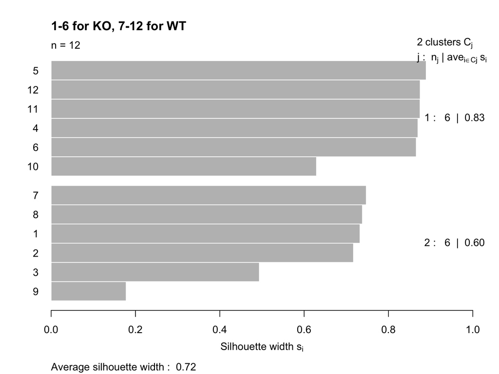

```r
# get the ions for PCA
pdreport <- dreport[,15:26]
indx <- sapply(pdreport, is.factor)
pdreport[indx] <- lapply(pdreport[indx], function(x) as.numeric(as.character(x)))
tpdreport <- data.frame(t(pdreport))
labels <- c(1,1,1,1,1,1,2,2,2,2,2,2)
# get the cluster
library(cluster)
clus <- kmeans(tpdreport, centers=2)
dissE <- daisy(tpdreport)
dE2   <- dissE^2
sk2   <- silhouette(clus$cl, dE2)
plot(sk2,main="1-6 for KO, 7-12 for WT")
```

# Hierarchical

```r
# Ward Hierarchical Clustering
d <- dist(tpdreport, method = "euclidean")
# distance matrix
fit <- hclust(d, method="ward")
```

```
## The "ward" method has been renamed to "ward.D"; note new "ward.D2"
```

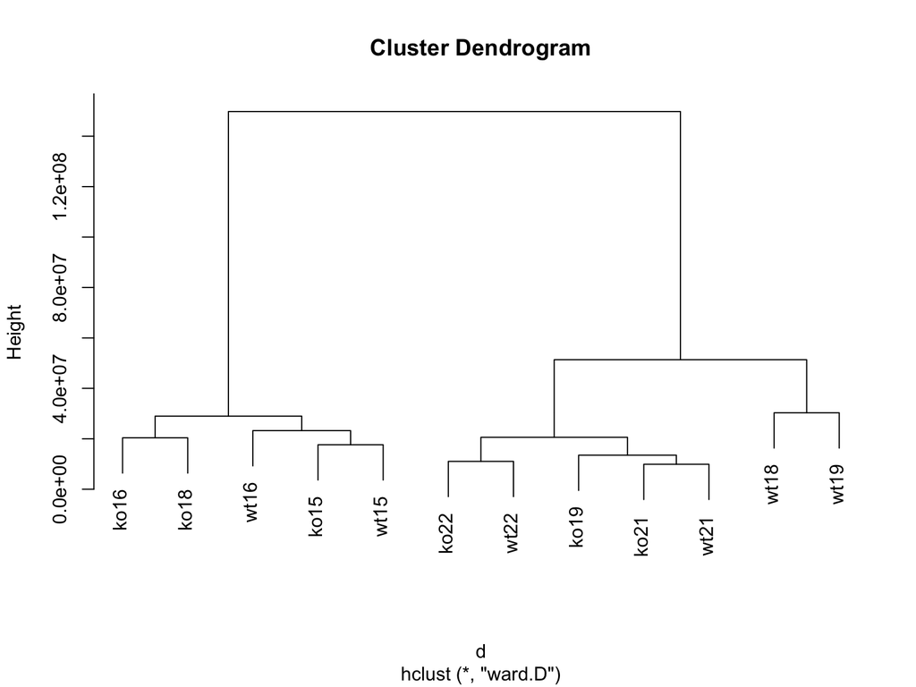

```r
# display dendogram
plot(fit)
```

# PCA

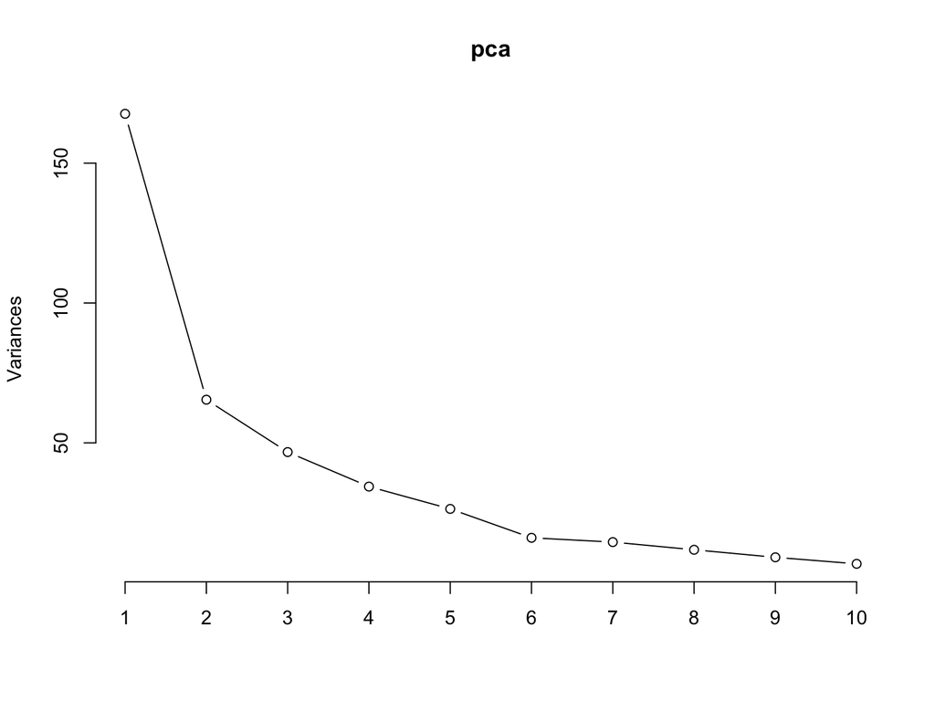

```r
# run PCA
pca <- prcomp(tpdreport, center=TRUE, scale=TRUE)
# loading plot
plot(pca, type = "l")
```

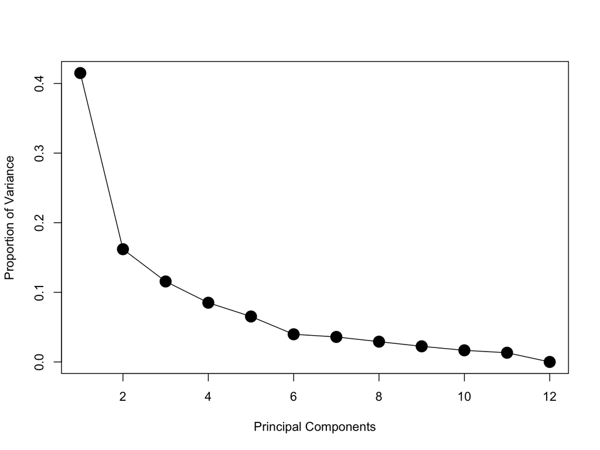

```r
CP <- (pca$sdev^2/sum(pca$sdev^2))
x <- 1:12
plot(CP~x,
     cex = 2,
     pch = 19,
     type = "o",
     xlab = "Principal Components",
     ylab = "Proportion of Variance")
```

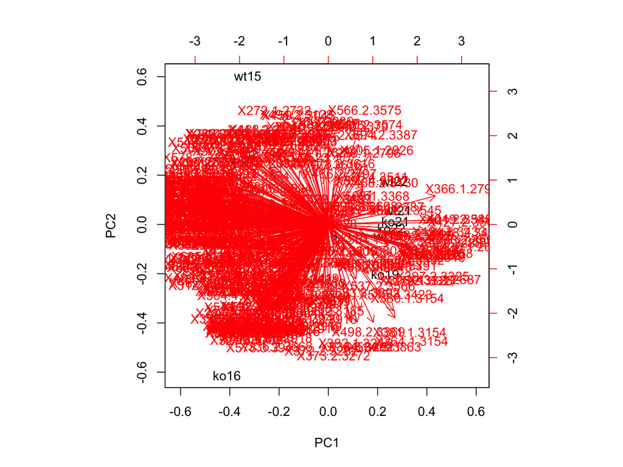

```r
# biplot
biplot(pca)
```

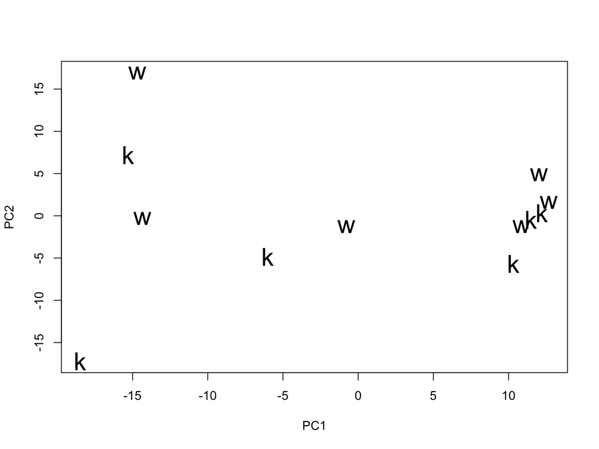

```r
plot(pca$x[,1],
     pca$x[,2],
     xlab="PC1",
     ylab="PC2",
     pch=rownames(tpdreport),
     cex=2)
```

# PLS-DA

```r
library(ropls)
dplsda <- opls(tpdreport, as.factor(labels))
```

```
## PLS-DA
## 12 samples x 404 variables and 1 response
## standard scaling of predictors and response(s)
##       R2X(cum) R2Y(cum) Q2(cum) RMSEE pre ort pR2Y  pQ2
## Total    0.738    0.994   0.835 0.052   4   0 0.05 0.05
```

```r
plot(dplsda)
```

[output not shown]

# Tree

```r
# install.packages('randomForest')
library(randomForest)
```

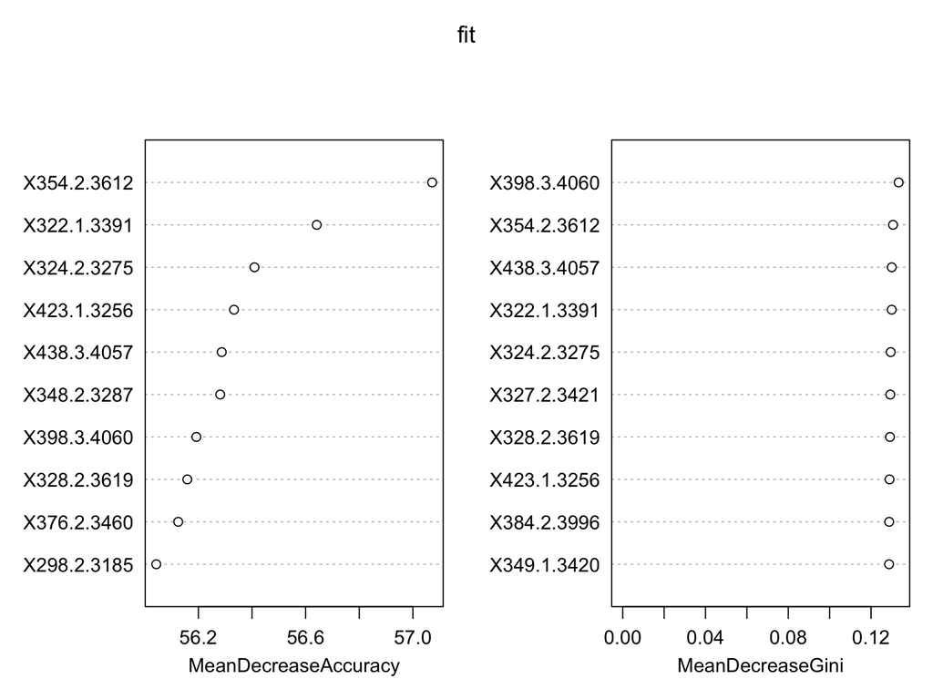

```r
# grow tree
fit <- randomForest(y=as.factor(labels),x = as.matrix(tpdreport), importance=TRUE,ntree=200000)
varImpPlot(fit, n.var = 10)
```

# Useful links

- [Workshop slides](https://docs.google.com/presentation/d/1wuOiLa6XMZcoM_IRirQgT3z3fhnoGy4SRZYDNPI2J2o/edit?usp=sharing)
- [The Elements of Statistical Learning: Data Mining, Inference, and Prediction.](http://statweb.stanford.edu/~tibs/ElemStatLearn/)
- [Multivariate Analysis in Metabolomics](http://www.ncbi.nlm.nih.gov/pmc/articles/PMC4465187/)
- [Ropls packages](http://bioconductor.org/packages/release/bioc/html/ropls.html)
- [A tutorial review: Metabolomics and partial least squares-discriminant analysis – a marriage of convenience or a shotgun wedding](http://www.sciencedirect.com/science/article/pii/S0003267015001889)